# Reproducible Research-Course Project 2

Sanket Tarafder

22/05/2021

# Exploring the U.S. National Oceanic and Atmospheric Administration’s (NOAA) storm database

Storms and other severe weather events can cause both public health and economic problems for communities and municipalities. Many severe events can result in fatalities, injuries, and property damage, and preventing such outcomes to the extent possible is a key concern.

This project involves exploring the U.S. National Oceanic and Atmospheric Administration’s (NOAA) storm database. This database tracks characteristics of major storms and weather events in the United States, including when and where they occur, as well as estimates of any fatalities, injuries, and property damage.

## Data

The data for this assignment come in the form of a comma-separated-value file compressed via the bzip2 algorithm to reduce its size. You can download the file from the course web site:

- [Storm Data](https://d396qusza40orc.cloudfront.net/repdata%2Fdata%2FStormData.csv.bz2) [47Mb]

There is also some documentation of the database available. Here you will find how some of the variables are constructed/defined.

- National Weather Service [Storm Data Documentation](https://d396qusza40orc.cloudfront.net/repdata%2Fpeer2_doc%2Fpd01016005curr.pdf)
- National Climatic Data Center Storm Events [FAQ](https://d396qusza40orc.cloudfront.net/repdata%2Fpeer2_doc%2FNCDC%20Storm%20Events-FAQ%20Page.pdf)

The events in the database start in the year 1950 and end in November 2011. In the earlier years of the database there are generally fewer events recorded, most likely due to a lack of good records. More recent years should be considered more complete.

## Assignment

The basic goal of this assignment is to explore the NOAA Storm Database and answer some basic questions about severe weather events. You must use the database to answer the questions below and show the code for your entire analysis. Your analysis can consist of tables, figures, or other summaries. You may use any R package you want to support your analysis.

### Questions

1. Across the United States, which types of events (as indicated in the EVTYPE variable) are most harmful with respect to population health?
2. Across the United States, which types of events have the greatest economic consequences?

### Mandatory Imports

```r
library(dplyr)
library(ggplot2)
library(ggpubr)
```

# Data Processing

### Loading the Data

At first the Data is loaded into R.

```r
filename <- "StormData.csv.bz2"
fileUrl <- "https://d396qusza40orc.cloudfront.net/repdata%2Fdata%2FStormData.csv.bz2"
if(!file.exists(filename)) {
  download.file(fileUrl, destfile = filename, method = "curl")
}

Storm.Data <- read.csv(filename)
head(Storm.Data)
```

```
##   STATE__           BGN_DATE BGN_TIME TIME_ZONE COUNTY COUNTYNAME STATE  EVTYPE
## 1       1  4/18/1950 0:00:00     0130       CST     97     MOBILE    AL TORNADO
## 2       1  4/18/1950 0:00:00     0145       CST      3    BALDWIN    AL TORNADO
## 3       1  2/20/1951 0:00:00     1600       CST     57    FAYETTE    AL TORNADO
## 4       1   6/8/1951 0:00:00     0900       CST     89    MADISON    AL TORNADO
## 5       1 11/15/1951 0:00:00     1500       CST     43    CULLMAN    AL TORNADO
## 6       1 11/15/1951 0:00:00     2000       CST     77 LAUDERDALE    AL TORNADO
##   BGN_RANGE BGN_AZI BGN_LOCATI END_DATE END_TIME COUNTY_END COUNTYENDN
## 1         0                                               0         NA
## 2         0                                               0         NA
## 3         0                                               0         NA
## 4         0                                               0         NA
## 5         0                                               0         NA
## 6         0                                               0         NA
##   END_RANGE END_AZI END_LOCATI LENGTH WIDTH F MAG FATALITIES INJURIES PROPDMG
```

[output cut: 20 more lines]

### Processing the Data

The Data contains total **902297** observations and total **37** variables but we are only interested in few variables.

The variables we are interested in are-

- `EVTYPE`: Types of events or natural calamities or weather events, e.g., Tornado, Hurricane, Avalanche, Flood, Hail, etc.
- `FATALITIES`: Number of death due to natural calamities or weather events.
- `INJURIES`: Number of people injured due to the weather events.
- `PROPDMG`: Damage of property due to weather events.
- `PROPDMGEXP`: Units for property damage.
- `CROPDMG`: Damage of crops due to weather events.
- `CROPDMGEXP`: Units for crop damage.

So, only these variables are selected for further analysis.

```r
Storm.Data <- Storm.Data[, c("EVTYPE", "FATALITIES", "INJURIES", "PROPDMG", "PROPDMGEXP", "CROPDMG", "CROPDMGEXP")]
head(Storm.Data)
```

```
##    EVTYPE FATALITIES INJURIES PROPDMG PROPDMGEXP CROPDMG CROPDMGEXP
## 1 TORNADO          0       15    25.0          K       0
## 2 TORNADO          0        0     2.5          K       0
## 3 TORNADO          0        2    25.0          K       0
## 4 TORNADO          0        2     2.5          K       0
## 5 TORNADO          0        2     2.5          K       0
## 6 TORNADO          0        6     2.5          K       0
```

Then, the same kind of weather events are grouped into 10 different types, i.e., Hail, Storm, Snow, Flood, Winter, Rain, Tornado, Wind, Heat and Others, in a new variable `EVENTS`.

```r
Storm.Data$EVENTS <- "OTHERS"

Storm.Data$EVENTS[grepl("Hail", Storm.Data$EVTYPE, ignore.case = TRUE)] <- "Hail"
Storm.Data$EVENTS[grepl("Storm", Storm.Data$EVTYPE, ignore.case = TRUE)] <- "Storm"
Storm.Data$EVENTS[grepl("Snow", Storm.Data$EVTYPE, ignore.case = TRUE)] <- "Snow"
Storm.Data$EVENTS[grepl("Flood", Storm.Data$EVTYPE, ignore.case = TRUE)] <- "Flood"
Storm.Data$EVENTS[grepl("Winter", Storm.Data$EVTYPE, ignore.case = TRUE)] <- "Winter"
Storm.Data$EVENTS[grepl("Rain", Storm.Data$EVTYPE, ignore.case = TRUE)] <- "Rain"
Storm.Data$EVENTS[grepl("Tornado", Storm.Data$EVTYPE, ignore.case = TRUE)] <- "Tornado"
Storm.Data$EVENTS[grepl("Wind", Storm.Data$EVTYPE, ignore.case = TRUE)] <- "Wind"
Storm.Data$EVENTS[grepl("Heat", Storm.Data$EVTYPE, ignore.case = TRUE)] <- "Heat"

table(Storm.Data$EVENTS)
```

```
##
##   Flood    Hail    Heat  OTHERS    Rain    Snow   Storm Tornado    Wind  Winter
##   82693  289270    2648   48970   12217   17632    3666   60699  364901   19601
```

Now explore the units of economical damage.

```r
sort(table(Storm.Data$PROPDMGEXP), decreasing = TRUE)
```

```
##
##             K      M      0      B      5      1      2      ?      m      H
## 465934 424665  11330    216     40     28     25     13      8      7      6
##      +      7      3      4      6      -      8      h
##      5      5      4      4      4      1      1      1
```

```r
sort(table(Storm.Data$CROPDMGEXP), decreasing = TRUE)
```

```
##
##             K      M      k      0      B      ?      2      m
## 618413 281832   1994     21     19      9      7      1      1
```

There are some mess in the units so, we are going to simplify the units taking

- **H** and **h** as 10^2
- **K** and **k** as 10^3
- **M** and **m** as 10^6
- **B** as 10^9
- The others are assumed as Dollars

and the units are updated in their respective places and the type is changed to numeric.

```r
Storm.Data$PROPDMGEXP[!grepl("K|M|B|H", Storm.Data$PROPDMGEXP, ignore.case = TRUE)] <- "0"
Storm.Data$PROPDMGEXP[grepl("H", Storm.Data$PROPDMGEXP, ignore.case = TRUE)] <- "2"
Storm.Data$PROPDMGEXP[grepl("K", Storm.Data$PROPDMGEXP, ignore.case = TRUE)] <- "3"
Storm.Data$PROPDMGEXP[grepl("M", Storm.Data$PROPDMGEXP, ignore.case = TRUE)] <- "6"
Storm.Data$PROPDMGEXP[grepl("B", Storm.Data$PROPDMGEXP, ignore.case = TRUE)] <- "9"

sort(table(Storm.Data$PROPDMGEXP), decreasing = TRUE)
```

```
##
##      0      3      6      9      2
## 466248 424665  11337     40      7
```

```r
Storm.Data$CROPDMGEXP[!grepl("K|M|B|H", Storm.Data$CROPDMGEXP, ignore.case = TRUE)] <- "0"
Storm.Data$CROPDMGEXP[grepl("H", Storm.Data$CROPDMGEXP, ignore.case = TRUE)] <- "2"
Storm.Data$CROPDMGEXP[grepl("K", Storm.Data$CROPDMGEXP, ignore.case = TRUE)] <- "3"
Storm.Data$CROPDMGEXP[grepl("M", Storm.Data$CROPDMGEXP, ignore.case = TRUE)] <- "6"
Storm.Data$CROPDMGEXP[grepl("B", Storm.Data$CROPDMGEXP, ignore.case = TRUE)] <- "9"

sort(table(Storm.Data$CROPDMGEXP), decreasing = TRUE)
```

```
##
##      0      3      6      9
## 618440 281853   1995      9
```

Now we update the damage data in `PROPDMG` and `CROPDMG`.

```r
Storm.Data$PROPDMG <- Storm.Data$PROPDMG * 10 ^ as.numeric(Storm.Data$PROPDMGEXP)
Storm.Data$CROPDMG <- Storm.Data$CROPDMG * 10 ^ as.numeric(Storm.Data$CROPDMGEXP)

Storm.Data <- Storm.Data[, names(Storm.Data) != "PROPDMGEXP"]
Storm.Data <- Storm.Data[, names(Storm.Data) != "CROPDMGEXP"]

head(Storm.Data)
```

```
##    EVTYPE FATALITIES INJURIES PROPDMG CROPDMG  EVENTS
## 1 TORNADO          0       15   25000       0 Tornado
## 2 TORNADO          0        0    2500       0 Tornado
## 3 TORNADO          0        2   25000       0 Tornado
## 4 TORNADO          0        2    2500       0 Tornado
## 5 TORNADO          0        2    2500       0 Tornado
## 6 TORNADO          0        6    2500       0 Tornado
```

# Analysis

As the data is now processed we should carry on our analysis.

### Summarising according to the effect on public health

We grouped the data according to the events and aggregated ta total **FATALITIES** and **INJURIES**.

```r
Storm.Data.Health <- Storm.Data %>% group_by(EVENTS) %>%
  summarise(Total.Fatalities = sum(FATALITIES), Total.Injuries = sum(INJURIES))

Storm.Data.Health$Total <- Storm.Data.Health$Total.Fatalities + Storm.Data.Health$Total.Injuries

Storm.Data.Health
```

```
## # A tibble: 10 x 4
##    EVENTS  Total.Fatalities Total.Injuries Total
##    <chr>              <dbl>          <dbl> <dbl>
##  1 Flood               1524           8604 10128
##  2 Hail                  15           1371  1386
##  3 Heat                3138           9224 12362
##  4 OTHERS              2626          12224 14850
##  5 Rain                 113            305   418
##  6 Snow                 159           1121  1280
##  7 Storm                206           2898  3104
##  8 Tornado             5636          91407 97043
##  9 Wind                1451          11498 12949
## 10 Winter               277           1876  2153
```

### Summarising according to the effect on public economy

```r
Storm.Data.Economy <- Storm.Data %>% group_by(EVENTS) %>%
  summarise(Total.Property.Damage = sum(PROPDMG), Total.Crop.Damage = sum(CROPDMG))

Storm.Data.Economy
```

```
## # A tibble: 10 x 3
##    EVENTS  Total.Property.Damage Total.Crop.Damage
##    <chr>                   <dbl>             <dbl>
##  1 Flood           167507743929.       12266906100
##  2 Hail             15733043543.        3046837473
##  3 Heat                20325750          904469280
##  4 OTHERS           97246712337.       23588880870
##  5 Rain              3262721192          806505800
##  6 Snow              1015569752.         134663100
##  7 Storm            61079559960         5739219500
##  8 Tornado          56993098029.         414961520
##  9 Wind             17742583230.        2159304538
## 10 Winter            6717295251           42444000
```

The **Total.Crop.Damage** variable the value for **OTHERS** category is much higher, almost double, than **Flood** which has the most Crop Damage value. So, we should explore which event is the reason for that.

```r
datasub <- Storm.Data
datasub <- Storm.Data[Storm.Data$EVENTS == "OTHERS",]
datasub <- datasub %>% group_by(EVTYPE) %>% summarise(total = sum(CROPDMG))
datasub[order(datasub$total, decreasing = TRUE), ]
```

```
## # A tibble: 391 x 2
##    EVTYPE                  total
##    <chr>                   <dbl>
##  1 DROUGHT           13972566000
##  2 HURRICANE          2741910000
##  3 HURRICANE/TYPHOON  2607872800
##  4 EXTREME COLD       1292973000
##  5 FROST/FREEZE       1094086000
##  6 FREEZE              446225000
##  7 WILDFIRE            295472800
##  8 DAMAGING FREEZE     262100000
##  9 EXCESSIVE WETNESS   142000000
## 10 HURRICANE ERIN      136010000
## # … with 381 more rows
```

We can see that **Drought** causes more Crop Damage than flood that we should consider this for the Crop Damage.

```r
Storm.Data$EVENTS[grepl("Drought", Storm.Data$EVTYPE, ignore.case = TRUE)] <- "Drought"
```

Now, we should recalculate and summarise the Dataset acoording to the effect of weather in the public economy.

```r
Storm.Data.Economy <- Storm.Data %>% group_by(EVENTS) %>%
  summarise(Total.Property.Damage = sum(PROPDMG), Total.Crop.Damage = sum(CROPDMG))

Storm.Data.Economy$Total <- Storm.Data.Economy$Total.Crop.Damage + Storm.Data.Economy$Total.Property.Damage

Storm.Data.Economy
```

```
## # A tibble: 11 x 4
##    EVENTS  Total.Property.Damage Total.Crop.Damage         Total
##    <chr>                   <dbl>             <dbl>         <dbl>
##  1 Drought           1046306000        13972621780  15018927780
##  2 Flood           167507743929.       12266906100 179774650029.
##  3 Hail             15733043543.        3046837473  18779881016.
##  4 Heat                20125750          904413500    924539250
##  5 OTHERS           96200606337.        9616314870 105816921207.
##  6 Rain              3262721192          806505800   4069226992
##  7 Snow              1015569752.         134663100   1150232852.
##  8 Storm            61079559960         5739219500  66818779460
##  9 Tornado          56993098029.         414961520  57408059549.
## 10 Wind             17742583230.        2159304538  19901887768.
## 11 Winter            6717295251           42444000   6759739251
```

# Results

So now we can visualize the result and draw a verdict.

### Across the United States, which types of events are most harmful with respect to population health?

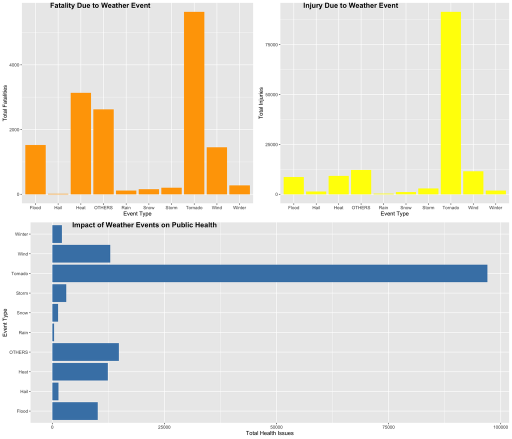

Effect of Weather Events on Public Health

```r
Storm.Data.Health$EVENTS <- as.factor(Storm.Data.Health$EVENTS)

# Plot of total
tp <- ggplot(Storm.Data.Health, aes(EVENTS, Total)) +
  geom_bar(stat = "identity", fill = "steelblue") +
  coord_flip() +
  ylab("Total Health Issues") +
  xlab("Event Type")

# Plot of Fatalities
fp <- ggplot(Storm.Data.Health, aes(EVENTS, Total.Fatalities)) +
  geom_bar(stat = "identity", fill = "orange") +
  ylab("Total Fatalities") +
  xlab("Event Type")

# Plot of Injuries
ip <- ggplot(Storm.Data.Health, aes(EVENTS, Total.Injuries)) +
  geom_bar(stat = "identity", fill = "yellow") +
  ylab("Total Injuries") +
  xlab("Event Type")

# Arranging all the plots
ggarrange(
  ggarrange(
    fp, ip, ncol = 2,
    labels = c("Fatality Due to Weather Event", "Injury Due to Weather Event")),
  ggarrange(tp, ncol = 1, labels = "Impact of Weather Events on Public Health"),
  nrow = 2
)
```

From the above figure we can conclude that **Tornado** is the most harmful event for the public health.

### Across the United States, which types of events have the greatest economic consequences?

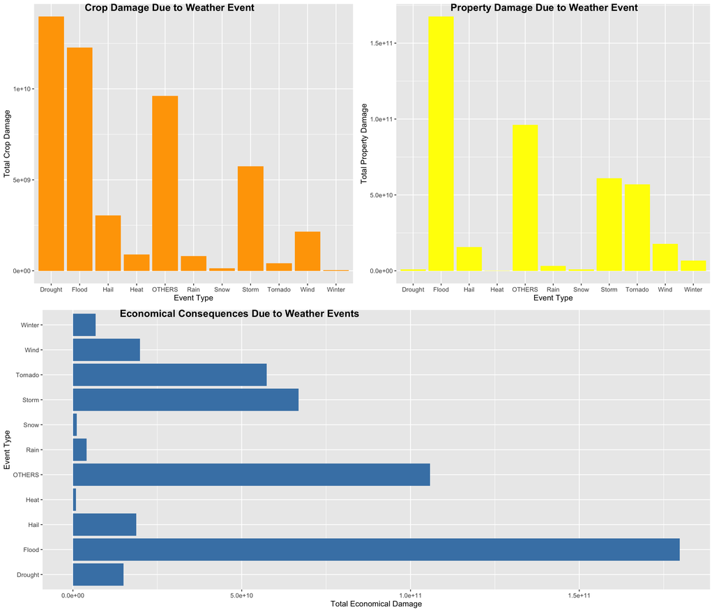

Effect of Weather Events on Public Economy

```r
Storm.Data.Economy$EVENTS <- as.factor(Storm.Data.Economy$EVENTS)

# Plot of total
tp <- ggplot(Storm.Data.Economy, aes(EVENTS, Total)) +
  geom_bar(stat = "identity", fill = "steelblue") +
  coord_flip() +
  ylab("Total Economical Damage") +
  xlab("Event Type")

# Plot of Crop Damage
cp <- ggplot(Storm.Data.Economy, aes(EVENTS, Total.Crop.Damage)) +
  geom_bar(stat = "identity", fill = "orange") +
  ylab("Total Crop Damage") +
  xlab("Event Type")

# Plot of Property Damage
pp <- ggplot(Storm.Data.Economy, aes(EVENTS, Total.Property.Damage)) +
  geom_bar(stat = "identity", fill = "yellow") +
  ylab("Total Property Damage") +
  xlab("Event Type")

# Arranging all the plots
ggarrange(
  ggarrange(
    cp, pp, ncol = 2,
    labels = c("Crop Damage Due to Weather Event", "Property Damage Due to Weather Event")),
  ggarrange(tp, ncol = 1, labels = "Economical Consequences Due to Weather Events"),
  nrow = 2
)
```

From the above figure we can conclude that the **Drought** caused more Crop Damage and **Flood** caused more Property Damage but The most devastating weather event with the greatest economic cosequences (to property and crops) is a **Flood**.